# DS606-Final Project

George Cruz

2020-12-05

# Youtube Most Liked Videos

```r
# load data
library(tidyverse)
library(scales)
library(infer)
library(psych)
library(httr)
library(jsonlite)
```

The Data Set was obtained from Kaggle. This dataset was collected using the YouTube API.

**Loading the Data.**

```r
#Get the videos csv
raw_video_df <- read_csv(file="https://raw.githubusercontent.com/georg4re/ds606/main/data/USvideos.csv",quote = "\"")
#get the categories JSON
url <- paste("https://raw.githubusercontent.com/georg4re/ds606/main/data/US_category_id.json", sep="")
res <- GET(url)
data <- fromJSON(rawToChar(res$content))

category_df <- data$items %>%
  flatten(.) %>%
  rename(category=snippet.title)
```

**Joining the data and the Categories**

```r
category_df <- category_df %>%
  rename(category_id = id)
category_df$category_id <- as.numeric(category_df$category_id)


video_df <- raw_video_df %>%
  left_join(category_df) %>%
  select(video_id,
         trending_date,
         title,
         channel_title,
         category,
         publish_time,
         tags,
         views,
         likes,
         dislikes,
         comment_count,
         comments_disabled,
         ratings_disabled,
         video_error_or_removed,
         description
         )
```

**A snippet**

```r
glimpse(video_df)
```

```
## Rows: 40,949
## Columns: 15
## $ video_id               <chr> "2kyS6SvSYSE", "1ZAPwfrtAFY", "5qpjK5DgCt4",...
## $ trending_date          <chr> "17.14.11", "17.14.11", "17.14.11", "17.14.1...
## $ title                  <chr> "WE WANT TO TALK ABOUT OUR MARRIAGE", "The T...
## $ channel_title          <chr> "CaseyNeistat", "LastWeekTonight", "Rudy Man...
## $ category               <chr> "People & Blogs", "Entertainment", "Comedy",...
## $ publish_time           <dttm> 2017-11-13 17:13:01, 2017-11-13 07:30:00, 2...
## $ tags                   <chr> "SHANtell martin", "last week tonight trump ...
## $ views                  <dbl> 748374, 2418783, 3191434, 343168, 2095731, 1...
## $ likes                  <dbl> 57527, 97185, 146033, 10172, 132235, 9763, 1...
## $ dislikes               <dbl> 2966, 6146, 5339, 666, 1989, 511, 2445, 778,...
## $ comment_count          <dbl> 15954, 12703, 8181, 2146, 17518, 1434, 1970,...
## $ comments_disabled      <lgl> FALSE, FALSE, FALSE, FALSE, FALSE, FALSE, FA...
## $ ratings_disabled       <lgl> FALSE, FALSE, FALSE, FALSE, FALSE, FALSE, FA...
## $ video_error_or_removed <lgl> FALSE, FALSE, FALSE, FALSE, FALSE, FALSE, FA...
## $ description            <chr> "SHANTELL'S CHANNEL - https://www.youtube.co...
```

```r
knitr::kable(head(video_df%>% select(-description),10))
```

| video_id | trending_date | title | channel_title | category | publish_time | tags | views | likes | dislikes | comment_count | comments_disabled | ratings_disabled | video_error_or_removed |
| --- | --- | --- | --- | --- | --- | --- | --- | --- | --- | --- | --- | --- | --- |
| 2kyS6SvSYSE | 17.14.11 | WE WANT TO TALK ABOUT OUR MARRIAGE | CaseyNeistat | People & Blogs | 2017-11-13 17:13:01 | SHANtell martin | 748374 | 57527 | 2966 | 15954 | FALSE | FALSE | FALSE |
| 1ZAPwfrtAFY | 17.14.11 | The Trump Presidency: Last Week Tonight with John Oliver (HBO) | LastWeekTonight | Entertainment | 2017-11-13 07:30:00 | last week tonight trump presidency“\|”last week tonight donald trump“\|”john oliver trump“\|”donald trump | 2418783 | 97185 | 6146 | 12703 | FALSE | FALSE | FALSE |
| 5qpjK5DgCt4 | 17.14.11 | Racist Superman \| Rudy Mancuso, King Bach & Lele Pons | Rudy Mancuso | Comedy | 2017-11-12 19:05:24 | racist superman“\|”rudy“\|”mancuso“\|”king“\|”bach“\|”racist“\|”superman“\|”love“\|”rudy mancuso poo bear black white official music video“\|”iphone x by pineapple“\|”lelepons“\|”hannahstocking“\|”rud… | 3191434 | 146033 | 5339 | 8181 | FALSE | FALSE | FALSE |
| puqaWrEC7tY | 17.14.11 | Nickelback Lyrics: Real or Fake? | Good Mythical Morning | Entertainment | 2017-11-13 11:00:04 | rhett and link“\|”gmm“\|”good mythical morning“\|”rhett and link good mythical morning“\|”good mythical morning rhett and link“\|”mythical morning“\|”Season 12“\|”nickelback lyrics“\|”nickelback lyric… | 343168 | 10172 | 666 | 2146 | FALSE | FALSE | FALSE |
| d380meD0W0M | 17.14.11 | I Dare You: GOING BALD!? | nigahiga | Entertainment | 2017-11-12 18:01:41 | ryan“\|”higa“\|”higatv“\|”nigahiga“\|”i dare you“\|”idy“\|”rhpc“\|”dares“\|”no truth“\|”comments“\|”comedy“\|”funny“\|”stupid“\|”fail | 2095731 | 132235 | 1989 | 17518 | FALSE | FALSE | FALSE |
| gHZ1Qz0KiKM | 17.14.11 | 2 Weeks with iPhone X | iJustine | Science & Technology | 2017-11-13 19:07:23 | ijustine“\|”week with iPhone X“\|”iphone x“\|”apple“\|”iphone“\|”iphone x review“\|”iphone x unboxing | 119180 | 9763 | 511 | 1434 | FALSE | FALSE | FALSE |
| 39idVpFF7NQ | 17.14.11 | Roy Moore & Jeff Sessions Cold Open - SNL | Saturday Night Live | Entertainment | 2017-11-12 05:37:17 | SNL“\|”Saturday Night Live“\|”SNL Season 43“\|”Episode 1730“\|”Tiffany Haddish“\|”Roy Moore“\|”Mikey Day“\|”Mike Pence“\|”Beck Bennett“\|”Jeff Sessions“\|”Kate McKinnon“\|”s43“\|”s43e5“\|”episode 5“\|… | 2103417 | 15993 | 2445 | 1970 | FALSE | FALSE | FALSE |
| nc99ccSXST0 | 17.14.11 | 5 Ice Cream Gadgets put to the Test | CrazyRussianHacker | Science & Technology | 2017-11-12 21:50:37 | 5 Ice Cream Gadgets“\|”Ice Cream“\|”Cream Sandwich Maker“\|”gadgets“\|”gadget review“\|”review“\|”unboxing“\|”kitchen gadgets“\|”Gadgets put to the Test“\|”testing“\|”10 Kitchen Gadgets“\|”7 Camping C… | 817732 | 23663 | 778 | 3432 | FALSE | FALSE | FALSE |
| jr9QtXwC9vc | 17.14.11 | The Greatest Showman \| Official Trailer 2 [HD] \| 20th Century FOX | 20th Century Fox | Film & Animation | 2017-11-13 14:00:23 | Trailer“\|”Hugh Jackman“\|”Michelle Williams“\|”Zac Efron“\|”Zendaya“\|”Rebecca Ferguson“\|”pasek and paul“\|”la la land“\|”moulin rouge“\|”high school musical“\|”hugh jackman musical“\|”zac efron mus… | 826059 | 3543 | 119 | 340 | FALSE | FALSE | FALSE |
| TUmyygCMMGA | 17.14.11 | Why the rise of the robots won’t mean the end of work | Vox | News & Politics | 2017-11-13 13:45:16 | vox.com“\|”vox“\|”explain“\|”shift change“\|”future of work“\|”automation“\|”robots“\|”jobs“\|”technological unemployment“\|”joss fong“\|”heidi shierholz“\|”martin ford“\|”rise of the robots“\|”humans… | 256426 | 12654 | 1363 | 2368 | FALSE | FALSE | FALSE |

### Research question

**You should phrase your research question in a way that matches up with the scope of inference your dataset allows for.** Is it possible to predict based on these variables or a combination of them the popularity of a youtube video in America?

### Cases

**What are the cases, and how many are there?** Each observation represents a video in Youtube. There are 40,949 observations.

### Data collection

**Describe the method of data collection.** Data was obtained from a [Kaggle data set.](https://www.kaggle.com/datasnaek/youtube-new?select=USvideos.csv)

### Type of study

**What type of study is this (observational/experiment)?** This is an observational study based on the obervations captured in this data.

### Data Source

**If you collected the data, state self-collected. If not, provide a citation/link.** Data was obtained from a [Kaggle data set.](https://www.kaggle.com/datasnaek/youtube-new?select=USvideos.csv)

### Dependent Variable

**What is the response variable? Is it quantitative or qualitative?** The response variable will be the prediction. It is qualitative.

### Relevant summary statistics

**Provide summary statistics for each the variables. Also include appropriate visualizations related to your research question (e.g. scatter plot, boxplots, etc). This step requires the use of R, hence a code chunk is provided below. Insert more code chunks as needed.**

*Summary Statistics*

```r
summary(video_df)
```

```
##    video_id         trending_date         title           channel_title
##  Length:40949       Length:40949       Length:40949       Length:40949
##  Class :character   Class :character   Class :character   Class :character
##  Mode  :character   Mode  :character   Mode  :character   Mode  :character
##
##
##
##    category          publish_time                     tags
##  Length:40949       Min.   :2006-07-23 08:24:11   Length:40949
##  Class :character   1st Qu.:2017-12-27 21:00:00   Class :character
##  Mode  :character   Median :2018-02-21 16:19:27   Mode  :character
##                     Mean   :2018-02-11 01:00:49
##                     3rd Qu.:2018-04-16 17:20:26
##                     Max.   :2018-06-14 01:31:53
##      views               likes            dislikes       comment_count
##  Min.   :      549   Min.   :      0   Min.   :      0   Min.   :      0
##  1st Qu.:   242329   1st Qu.:   5424   1st Qu.:    202   1st Qu.:    614
##  Median :   681861   Median :  18091   Median :    631   Median :   1856
##  Mean   :  2360785   Mean   :  74267   Mean   :   3711   Mean   :   8447
##  3rd Qu.:  1823157   3rd Qu.:  55417   3rd Qu.:   1938   3rd Qu.:   5755
##  Max.   :225211923   Max.   :5613827   Max.   :1674420   Max.   :1361580
##  comments_disabled ratings_disabled video_error_or_removed description
##  Mode :logical     Mode :logical    Mode :logical          Length:40949
##  FALSE:40316       FALSE:40780      FALSE:40926            Class :character
##  TRUE :633         TRUE :169        TRUE :23               Mode  :character
##
##
##
```

```r
describe(video_df %>% select(views, likes, dislikes))
```

```
##          vars     n      mean         sd median    trimmed       mad min
## views       1 40949 2360784.6 7394113.76 681861 1054836.27 813077.11 549
## likes       2 40949   74266.7  228885.34  18091   32156.33  23496.24   0
## dislikes    3 40949    3711.4   29029.71    631    1137.46    797.64   0
##                max     range  skew kurtosis       se
## views    225211923 225211374 12.24   232.34 36539.66
## likes      5613827   5613827 10.92   177.82  1131.09
## dislikes   1674420   1674420 40.19  1987.08   143.46
```

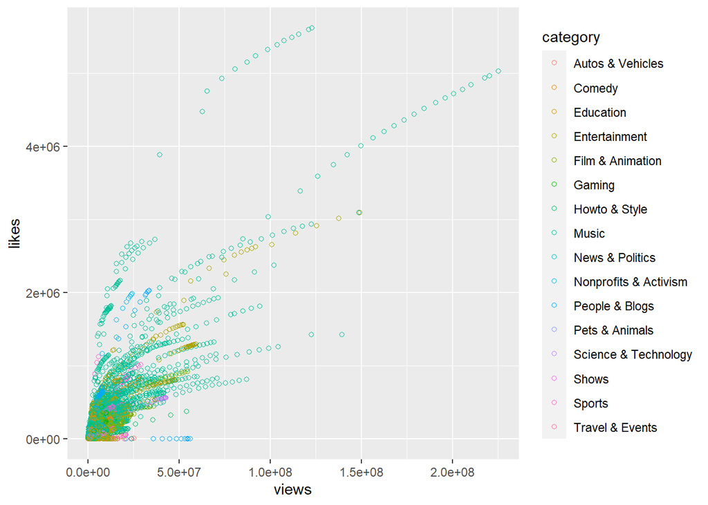

```r
ggplot(video_df, aes(x=views, y=likes, color = category)) +
    geom_point(shape=1)
```

We see a clear tendency of some categories to gather more views than others.

```r
video_categories <- video_df %>%
  group_by(category) %>%
  summarise(
         views_sum = sum(views),
         likes_sum = sum(likes),
         dislikes_sum = sum(dislikes))
knitr::kable(video_categories)
```

| category | views_sum | likes_sum | dislikes_sum |
| --- | --- | --- | --- |
| Autos & Vehicles | 520690717 | 4245656 | 243010 |
| Comedy | 5117426208 | 216346746 | 7230391 |
| Education | 1180629990 | 49257772 | 1351972 |
| Entertainment | 20604388195 | 530516491 | 42987663 |
| Film & Animation | 7284156721 | 165997476 | 6075148 |
| Gaming | 2141218625 | 69038284 | 9184466 |
| Howto & Style | 4078545064 | 162880075 | 5473899 |
| Music | 40132892190 | 1416838584 | 51179008 |
| News & Politics | 1473765704 | 18151033 | 4180049 |
| Nonprofits & Activism | 168941392 | 14815646 | 3310381 |
| People & Blogs | 4917191726 | 186615999 | 10187901 |
| Pets & Animals | 764651989 | 19370702 | 527379 |
| Science & Technology | 3487756816 | 82532638 | 4548402 |
| Shows | 51501058 | 1082639 | 24508 |
| Sports | 4404456673 | 98621211 | 5133551 |
| Travel & Events | 343557084 | 4836246 | 340427 |

[figure not shown]

```r
ggplot(video_categories, aes(factor(category), likes_sum, fill = category)) +
  geom_bar(stat="identity", position = "dodge") +
  scale_fill_brewer(palette = "Set1") +
  theme(axis.title.x=element_blank(),
        axis.text.x=element_blank(),
        axis.ticks.x=element_blank())
```

We can see the *Music* category seems to be the one gathering more likes. Further analysis is needed to identify and analyse the tags associated with the different videos and how the presence of these tags might help answer the initial question. …